# HW1

```python
!python --version
!pwd
import sys
sys.path.insert(1, '../yojin_env/lib/python3.6/site-packages')
```

```
Python 3.6.9
/home/emma/bilab/yojin/製造數據
```

**Assignment 1** Show all your analysis result including Python code in your report.

Upload your “zip” file including (1) MS Word/LaTeX pdf report (answering each question and its sub-questions) and Python code; or

(2) notebook (including answer and code), with file name: “MDS_Assignment1_ID_Name.zip” to NTU COOL by due.

Due Date: 5pm, Oct. 7, 2022

# (35%) Linear Regression Analysis for Wine Quality

For the attached metal furnace dataset (MDS_Assignment1_furnace.csv),

Please answer the following questions by using Python software and package:

```python
import numpy as np
import pandas as pd
pd.set_option('display.float_format', lambda x: '%.10f' % x)
df = pd.read_csv("./MDS_Assignment1_furnace.csv")
df
```

|  | f0 | f1 | f2 | f3 | f4 | f5 | f6 | f7 | f8 | f9 | ... | f19 | f20 | f21 | f22 | f23 | f24 | f25 | f26 | f27 | grade |
| --- | --- | --- | --- | --- | --- | --- | --- | --- | --- | --- | --- | --- | --- | --- | --- | --- | --- | --- | --- | --- | --- |
| 0 | 1.8485637818 | -0.2642501068 | -0.4614228192 | 0.4093999099 | 1.3054545536 | 2.3293984368 | 0.3709645251 | 0.0901669635 | 0.1079583793 | 0.0000000000 | ... | 0.0855051412 | 0.2332847374 | -1.0806628373 | 0.4432570741 | -0.4061212538 | -0.6876869489 | 0.2718856223 | 3.7272181153 | 0.1021285842 | 2 |
| 1 | -0.8250976755 | -0.2642501068 | 3.0323965159 | -2.4425994626 | 1.3054545536 | -0.2761441317 | 0.3709645251 | 0.0901669635 | 0.1079583793 | 0.0000000000 | ... | 0.0855051412 | 0.2332847374 | -1.0806628373 | -0.2325458718 | -0.4063660655 | -0.6876869489 | 0.2718856223 | -0.2324721374 | 0.1021285842 | 4 |
| 2 | 1.8485637818 | -0.2642501068 | -0.4614228192 | 0.4093999099 | 1.3054545536 | 2.3293984368 | 0.3709645251 | 0.0901669635 | 0.1079583793 | 0.0000000000 | ... | 0.0855051412 | 0.2332847374 | 0.9253579984 | 1.4597820395 | 1.2218764143 | 1.8777769650 | 0.2718856223 | -0.2324721374 | 0.1021285842 | 2 |
| 3 | 0.5117330531 | -0.2642501068 | -0.4614228192 | 0.4093999099 | -0.5257260419 | -0.2761441317 | 0.3709645251 | 0.0901669635 | 0.1079583793 | 0.0000000000 | ... | 0.0855051412 | 0.2332847374 | 0.9253579984 | -0.0080303689 | -0.4063660655 | 1.5045229939 | 0.2718856223 | -0.2324721374 | 0.1021285842 | 2 |
| 4 | -0.8250976755 | -0.2642501068 | -0.4614228192 | 0.4093999099 | -0.5257260419 | -0.2761441317 | 0.3709645251 | 0.0901669635 | 0.1079583793 | 0.0000000000 | ... | 0.0855051412 | 0.2332847374 | 0.9253579984 | -0.5732678913 | -1.1647926484 | 1.8777769650 | 0.2718856223 | -0.2324721374 | 0.1021285842 | 2 |
| ... | ... | ... | ... | ... | ... | ... | ... | ... | ... | ... | ... | ... | ... | ... | ... | ... | ... | ... | ... | ... | ... |
| 615 | -0.8250976755 | -0.2642501068 | 2.0048025938 | -2.4425994626 | 1.3054545536 | -0.2761441317 | 0.3709645251 | 0.0901669635 | 0.1079583793 | 0.0000000000 | ... | 0.0855051412 | 0.2332847374 | -1.0806628373 | -0.6849615334 | -0.4061212538 | -0.6876869489 | 0.2718856223 | -0.2324721374 | 0.1021285842 | 2 |
| 616 | -0.3794874327 | 3.8094066035 | -0.4614228192 | 0.4093999099 | 1.3054545536 | -0.2761441317 | 0.3709645251 | 0.0901669635 | 0.1079583793 | 0.0000000000 | ... | 0.0855051412 | 0.2332847374 | -1.0806628373 | 2.2484068461 | -0.3326777500 | -0.6876869489 | 0.2718856223 | 4.5191561659 | 0.1021285842 | 2 |
| 617 | -0.8250976755 | -0.2642501068 | -0.4614228192 | 0.4093999099 | -0.5257260419 | -0.2761441317 | 0.3709645251 | 0.0901669635 | 0.1079583793 | 0.0000000000 | ... | 0.0855051412 | 0.2332847374 | -1.0806628373 | -1.0234271156 | 1.3320416700 | -0.6876869489 | 0.2718856223 | -0.2324721374 | 0.1021285842 | 2 |
| 618 | -0.8250976755 | -0.2642501068 | 2.0048025938 | -2.4425994626 | 1.3054545536 | -0.2761441317 | 0.3709645251 | 0.0901669635 | 0.1079583793 | 0.0000000000 | ... | 0.0855051412 | 0.2332847374 | -1.0806628373 | 3.1509817321 | -1.7770666586 | -0.6876869489 | 0.2718856223 | -0.2324721374 | 0.1021285842 | 2 |
| 619 | -0.3794874327 | 3.0687417471 | -0.4614228192 | 0.4093999099 | 1.3054545536 | -0.2761441317 | 0.3709645251 | 0.0901669635 | 0.1079583793 | 0.0000000000 | ... | 0.0855051412 | 0.2332847374 | -1.0806628373 | 1.1201882386 | 0.3038326165 | -0.6876869489 | 0.2718856223 | -0.2324721374 | 0.1021285842 | 2 |

620 rows × 29 columns

## (a) (10%) Show the results of regression analysis as follows.

```python
import statsmodels.api as sm
X = df.drop(columns=['grade'])
y = df['grade']
mod = sm.OLS(y, sm.add_constant(X))
res = mod.fit()

# res.summary()
df_1 = pd.DataFrame()
# df_1['variable'] = res.var
df_1['estimate'] = res.params
df_1['std. error'] = res.bse
df_1['t-value'] = res.tvalues
df_1['p-value'] = res.pvalues
# display(df_1)
df_1= df_1.iloc[1: , :]
display(df_1)
print("R-squared: ",res.rsquared,", Adjusted R-squared: ",res.rsquared_adj)
```

|  | estimate | std. error | t-value | p-value |
| --- | --- | --- | --- | --- |
| f0 | -0.0055464354 | 0.0248100357 | -0.2235561224 | 0.8231798306 |
| f1 | 0.0439757930 | 0.0279940268 | 1.5708991540 | 0.1167403661 |
| f2 | 0.3139591583 | 0.0347742507 | 9.0284952692 | 0.0000000000 |
| f3 | 0.0185854695 | 0.0415374698 | 0.4474386532 | 0.6547220406 |
| f4 | -0.0034761208 | 0.0381991202 | -0.0910000227 | 0.9275233546 |
| f5 | -0.0739929207 | 0.0298024334 | -2.4827811764 | 0.0133120665 |
| f6 | -0.0710496406 | 0.0259138225 | -2.7417661250 | 0.0062957076 |
| f7 | 0.0235193314 | 0.0275628507 | 0.8532982170 | 0.3938390614 |
| f8 | 0.0410135299 | 0.0188959333 | 2.1704950565 | 0.0303661365 |
| f9 | -0.0000000000 | 0.0000000000 | -0.9092568237 | 0.3635845967 |
| f10 | -0.0445947265 | 0.0210448996 | -2.1190277615 | 0.0345038582 |
| f11 | -0.0291534644 | 0.0202713824 | -1.4381586709 | 0.1509174479 |
| f12 | -0.0005926334 | 0.0220014653 | -0.0269360896 | 0.9785197860 |
| f13 | 0.0336314071 | 0.0238245944 | 1.4116255914 | 0.1585855951 |
| f14 | -0.1832175476 | 0.0205910612 | -8.8979167124 | 0.0000000000 |
| f15 | -0.1060874766 | 0.0190625554 | -5.5652285084 | 0.0000000397 |
| f16 | -0.0357714163 | 0.0203700430 | -1.7560795673 | 0.0795918921 |
| f17 | 0.0633103768 | 0.0185724862 | 3.4088261541 | 0.0006967770 |
| f18 | -0.1903848281 | 0.0207066129 | -9.1943973947 | 0.0000000000 |
| f19 | 0.0277546560 | 0.0264151011 | 1.0507117106 | 0.2938197302 |
| f20 | 0.0125629063 | 0.0195193935 | 0.6436115067 | 0.5200766296 |
| f21 | -0.0356736859 | 0.0282468608 | -1.2629256833 | 0.2071130863 |
| f22 | 0.0746800928 | 0.0211379088 | 3.5329934247 | 0.0004429125 |
| f23 | -0.0087688697 | 0.0198388857 | -0.4420041422 | 0.6586476274 |
| f24 | 0.0193027419 | 0.0241162884 | 0.8004026820 | 0.4237986072 |
| f25 | -0.0679217117 | 0.0199424204 | -3.4058910715 | 0.0007041639 |
| f26 | -0.0360055794 | 0.0221541882 | -1.6252267524 | 0.1046464698 |
| f27 | -0.0062014403 | 0.0191689000 | -0.3235157083 | 0.7464189632 |

```
R-squared:  0.4953759883189155 , Adjusted R-squared:  0.47236104184021743
```

## (b) (5%) The fitting of the linear regression is a good idea? If yes, why? If no, why? What’s the possible reason of poor fitting?

由於 R-squared: 0.4953759883189155 , Adjusted R-squared: 0.47236104184021743，

兩者皆小於0.5，代表對於此資料集而言線性回歸模型的預測能力相對較弱，故線性回歸並不是預測此資料集最佳的方法。

參考：https://medium.com/@erika.dauria/looking-at-r-squared-721252709098

## (c) (5%) Based on the results, rank the independent variables by p-values and which one are statistically significant variables with p-values<0.01? (i.e. 重要變數挑選 )

```python
pd.set_option('display.float_format', lambda x: '%.5f' % x)
df_1_sort = df_1.sort_values(['p-value'])
print("rank the independent variables by p-values:")
display(df_1_sort)
important_var = [v for v in df_1_sort.index if df_1_sort['p-value'][v] < 0.01]
pd.set_option('display.float_format', lambda x: '%.30f' % x)
print("\nsignificant variables with p-values<0.01: （依序為）")
display(df_1_sort['p-value'][important_var])
```

```
rank the independent variables by p-values:
```

|  | estimate | std. error | t-value | p-value |
| --- | --- | --- | --- | --- |
| f18 | -0.19038 | 0.02071 | -9.19440 | 0.00000 |
| f2 | 0.31396 | 0.03477 | 9.02850 | 0.00000 |
| f14 | -0.18322 | 0.02059 | -8.89792 | 0.00000 |
| f15 | -0.10609 | 0.01906 | -5.56523 | 0.00000 |
| f22 | 0.07468 | 0.02114 | 3.53299 | 0.00044 |
| f17 | 0.06331 | 0.01857 | 3.40883 | 0.00070 |
| f25 | -0.06792 | 0.01994 | -3.40589 | 0.00070 |
| f6 | -0.07105 | 0.02591 | -2.74177 | 0.00630 |
| f5 | -0.07399 | 0.02980 | -2.48278 | 0.01331 |
| f8 | 0.04101 | 0.01890 | 2.17050 | 0.03037 |
| f10 | -0.04459 | 0.02104 | -2.11903 | 0.03450 |
| f16 | -0.03577 | 0.02037 | -1.75608 | 0.07959 |
| f26 | -0.03601 | 0.02215 | -1.62523 | 0.10465 |
| f1 | 0.04398 | 0.02799 | 1.57090 | 0.11674 |
| f11 | -0.02915 | 0.02027 | -1.43816 | 0.15092 |
| f13 | 0.03363 | 0.02382 | 1.41163 | 0.15859 |
| f21 | -0.03567 | 0.02825 | -1.26293 | 0.20711 |
| f19 | 0.02775 | 0.02642 | 1.05071 | 0.29382 |
| f9 | -0.00000 | 0.00000 | -0.90926 | 0.36358 |
| f7 | 0.02352 | 0.02756 | 0.85330 | 0.39384 |
| f24 | 0.01930 | 0.02412 | 0.80040 | 0.42380 |
| f20 | 0.01256 | 0.01952 | 0.64361 | 0.52008 |
| f3 | 0.01859 | 0.04154 | 0.44744 | 0.65472 |
| f23 | -0.00877 | 0.01984 | -0.44200 | 0.65865 |
| f27 | -0.00620 | 0.01917 | -0.32352 | 0.74642 |
| f0 | -0.00555 | 0.02481 | -0.22356 | 0.82318 |
| f4 | -0.00348 | 0.03820 | -0.09100 | 0.92752 |
| f12 | -0.00059 | 0.02200 | -0.02694 | 0.97852 |

```
significant variables with p-values<0.01: （依序為）
```

```
f18   0.000000000000000000635589479596
f2    0.000000000000000002430367850095
f14   0.000000000000000006896905393343
f15   0.000000039713256771779729658885
f22   0.000442912478352032793187803561
f17   0.000696777004896294077304630399
f25   0.000704163943691985178864600758
f6    0.006295707579197161798956194900
Name: p-value, dtype: float64
```

## (d) (15%) Testify the underlying assumptions of regression (1) Normality, (2) Independence, and (3) Homogeneity of Variance with respect to residual.

### (1) Normality

H0: The residual is normal distribution. H1: The residual is not normal distribution.

Shapiro-Wilk test 是最常使用的常態性檢測工具，可以告訴我們隨機抽取出來的樣本是否來自於常態分布，當統計值 W 愈小，表示資料愈不可能來自常態分布。

資料來源： https://epicdatastudio.xyz/normality-test/ https://www.statology.org/shapiro-wilk-test-python/

```python
# pd.set_option('display.float_format', lambda x: '%.5f' % x)
# np.set_printoptions(suppress=None)
from scipy.stats import shapiro

#perform Shapiro-Wilk test
shap_result = shapiro(res.resid)
print("ShapiroResult statistic:")
print("{:.10f}".format(shap_result[0]))
print("ShapiroResult pvalue:")
print("{:.20f}".format(shap_result[1]))
```

```
ShapiroResult statistic:
0.9345124364
ShapiroResult pvalue:
0.00000000000000075360
```

Kolmogorov-Smirnov test 可檢定樣本是否吻合某個特定的分布 (ex:常態分布)，統計值 D 愈大，表示資料愈不可能來自常態分布。

資料來源：https://peilee-98185.medium.com/%E6%9F%AF%E7%88%BE%E8%8E%AB%E5%93%A5%E6%B4%9B%E5%A4%AB-%E6%96%AF%E7%B1%B3%E7%88%BE%E8%AB%BE%E5%A4%AB%E6%AA%A2%E9%A9%97-kolmogorov-smirnov-test-8d723edd5e1b

```python
from scipy.stats import kstest
k_result = kstest(res.resid, 'norm')
print("KstestResult statistic:")
print("{:.10f}".format(k_result[0]))
print("KstestResult pvalue:")
print("{:.60f}".format(k_result[1]))
```

```
KstestResult statistic:
0.2661699066
KstestResult pvalue:
0.000000000000000000000000000000000000002879954970164647316860
```

如果樣本數少於等於50，則看 Shapiro-Wilk的 W 值，來檢測是否為常態分佈； 如果樣本數大於50，則看 Kolomogorov 的 D 值。

由上述兩個測試結果可見，p-value皆<0.05，代表拒絕虛無假設H0並有充足的證據說明residual data並非常態分佈資料。

資料來源：http://sub.chimei.org.tw/57300/images/05_research/1081125.pdf

### (2) Independence

獨立性(Independency) : 誤差項之間應該要相互獨立，否則在估計迴歸參數時會降低統計的檢定力。

我們可以藉由Durbin-Watson test來檢查。

H0: The errors is independent. H1: The errors is not independent.

資料來源：https://www.yongxi-stat.com/simple-regression-analysis/ https://www.cupoy.com/qa/collection/0000017705894B9C000000036375706F795F72656C656173654355/00000177151DDEC3000000236375706F795F70726572656C656173654349/0000017F4D85E68A000000106375706F795F72656C656173655155455354 https://www.statology.org/durbin-watson-test-python/

```python
from statsmodels.stats.stattools import durbin_watson
import scipy
# Using statsmodels.durbin_watson() method
tstatistic = durbin_watson(res.resid)
print("durbin_watson statistic:")
print("{:.10f}".format(tstatistic))
```

```
durbin_watson statistic:
2.0040534805
```

由上述測試結果可見，dw值在1.5~2.55之間，代表接受虛無假設H0，說明residual data相互獨立。

### (3) Homogeneity

殘差變異數一致性：使用 Breusch-Pagan Test 檢測殘差變異數是否一致。

\begin{cases}H_{0}: \sigma^{1} = \sigma^{2} = ... = \sigma^{n} \end{cases}\begin{cases}H_{1}: \sigma^{i} \not= \sigma^{j} \end{cases}

資料來源：https://www.geeksforgeeks.org/how-to-perform-a-breusch-pagan-test-in-python/

```python
from statsmodels.compat import lzip
import statsmodels.stats.api as sms
names = ['Lagrange multiplier statistic', 'p-value', 'f-value', 'f p-value']
# Get the test result
het_result = sms.het_breuschpagan(res.resid, res.model.exog)

print("Breusch-Pagan Test Result:")
print(names[0])
print("{:.10f}".format(het_result[0]))
print(names[1])
print("{:.30f}".format(het_result[1]))
print(names[2])
print("{:.10f}".format(het_result[2]))
print(names[3])
print("{:.30f}".format(het_result[3]))
```

```
Breusch-Pagan Test Result:
Lagrange multiplier statistic
140.6203496518
p-value
0.000000000000000058718429301051
f-value
6.4317109996
f p-value
0.000000000000000000053118156754
```

由上述測試結果可見，p-value與f p-value皆<0.05，拒絕虛無假設H0，代表殘差變異數不具有同質性。

# (35%) Association Rule- Market Basket Analysis

```python
pd.set_option('display.float_format', lambda x: '%.1f' % x)
```

## (1) (10%) How to handle the raw dataset via data preprocessing?

- Load DataSet
- Do One-Hot-Encode
  - using loop to get all items set
  - using loop to get df_2
    - if a row got the item, value=1; if no, value=0

```python
import csv

set_all = set()
item_count = 0
with open("./MDS_Assignment1_groceries.csv", "r") as f:
    reader = csv.reader(f, delimiter=";")
    for i, line in enumerate(reader):
        items_list = line[0].split(',')
        for item in items_list:
            item_count += 1
            set_all.add(item)
# print(set_all)
# print(len(set_all))
# print(item_count)

# initial df with a row of zeros
df_2 = pd.DataFrame(np.zeros((1,len(set_all)), dtype=int), columns=list(set_all))
with open("./MDS_Assignment1_groceries.csv", "r") as f:
    reader = csv.reader(f, delimiter=";")
    for i, line in enumerate(reader):
        items_list = line[0].split(',')
        tmp_dic = {}
        for item in items_list:
            tmp_dic[item] = 1
        df_2 = df_2.append(tmp_dic, ignore_index=True)

# remove the first initial row of zeros
df_2 = df_2.iloc[1: , :]
df_2 = df_2.fillna(0)
df_2 = df_2.reset_index(drop=True)
df_2.info()
df_2.head(5)
```

```
<class 'pandas.core.frame.DataFrame'>
RangeIndex: 9835 entries, 0 to 9834
Columns: 169 entries, mustard to cat food
dtypes: float64(169)
memory usage: 12.7 MB
```

|  | mustard | fish | curd | prosecco | beef | pip fruit | onions | softener | tea | liquor (appetizer) | ... | pork | meat spreads | cocoa drinks | white bread | skin care | dessert | sound storage medium | baking powder | frozen dessert | cat food |
| --- | --- | --- | --- | --- | --- | --- | --- | --- | --- | --- | --- | --- | --- | --- | --- | --- | --- | --- | --- | --- | --- |
| 0 | 0.0 | 0.0 | 0.0 | 0.0 | 0.0 | 0.0 | 0.0 | 0.0 | 0.0 | 0.0 | ... | 0.0 | 0.0 | 0.0 | 0.0 | 0.0 | 0.0 | 0.0 | 0.0 | 0.0 | 0.0 |
| 1 | 0.0 | 0.0 | 0.0 | 0.0 | 0.0 | 0.0 | 0.0 | 0.0 | 0.0 | 0.0 | ... | 0.0 | 0.0 | 0.0 | 0.0 | 0.0 | 0.0 | 0.0 | 0.0 | 0.0 | 0.0 |
| 2 | 0.0 | 0.0 | 0.0 | 0.0 | 0.0 | 0.0 | 0.0 | 0.0 | 0.0 | 0.0 | ... | 0.0 | 0.0 | 0.0 | 0.0 | 0.0 | 0.0 | 0.0 | 0.0 | 0.0 | 0.0 |
| 3 | 0.0 | 0.0 | 0.0 | 0.0 | 0.0 | 1.0 | 0.0 | 0.0 | 0.0 | 0.0 | ... | 0.0 | 1.0 | 0.0 | 0.0 | 0.0 | 0.0 | 0.0 | 0.0 | 0.0 | 0.0 |
| 4 | 0.0 | 0.0 | 0.0 | 0.0 | 0.0 | 0.0 | 0.0 | 0.0 | 0.0 | 0.0 | ... | 0.0 | 0.0 | 0.0 | 0.0 | 0.0 | 0.0 | 0.0 | 0.0 | 0.0 | 0.0 |

5 rows × 169 columns

## (2) (10%) What’s the top 5 association rules? Show the support, confidence, and lift to each specific rule, respectively?

Use “association rule” to find the potential patterns which satisfy the following criterion:

- Set the minimum support to 0.001
- Set the minimum confidence of 0.15

Steps:

- use apriori with min_support=0.001 to get frquent_itemsets
- use association_rules() funciton to get the rules by frequent_items
- fliter rules by minimum confidence of 0.15 and show the top 5 rules & top 5 rules sorted by lift

```python
# !pip install mlxtend
# !pip3 install mlxtend
# !pip list
# !conda install mlxtend --y
```

```python
import mlxtend
from mlxtend.frequent_patterns import apriori
from mlxtend.frequent_patterns import association_rules
pd.set_option('display.float_format', lambda x: '%.5f' % x)
frequent_itemsets = apriori(df_2, min_support=0.001, use_colnames=True)
```

```python
frequent_itemsets
```

|  | support | itemsets |
| --- | --- | --- |
| 0 | 0.01200 | (mustard) |
| 1 | 0.00295 | (fish) |
| 2 | 0.05328 | (curd) |
| 3 | 0.00203 | (prosecco) |
| 4 | 0.05247 | (beef) |
| ... | ... | ... |
| 13487 | 0.00132 | (root vegetables, whole milk, other vegetables... |
| 13488 | 0.00112 | (root vegetables, whole milk, other vegetables... |
| 13489 | 0.00102 | (butter, whole milk, other vegetables, tropica... |
| 13490 | 0.00112 | (butter, root vegetables, whole milk, other ve... |
| 13491 | 0.00102 | (root vegetables, oil, whole milk, other veget... |

13492 rows × 2 columns

```python
rules = association_rules(frequent_itemsets, metric="lift", min_threshold=1)
print("top 5 association rules：")
display(rules[ (rules['support'] >= 0.001) &
           (rules['confidence'] >= 0.15) ].head(5).drop(columns=['leverage', 'conviction']))
```

```
top 5 association rules：
```

|  | antecedents | consequents | antecedent support | consequent support | support | confidence | lift |
| --- | --- | --- | --- | --- | --- | --- | --- |
| 12 | (mustard) | (yogurt) | 0.01200 | 0.13950 | 0.00234 | 0.19492 | 1.39722 |
| 14 | (mustard) | (frankfurter) | 0.01200 | 0.05897 | 0.00254 | 0.21186 | 3.59256 |
| 16 | (mustard) | (shopping bags) | 0.01200 | 0.09853 | 0.00203 | 0.16949 | 1.72028 |
| 24 | (mustard) | (soda) | 0.01200 | 0.17438 | 0.00234 | 0.19492 | 1.11778 |
| 28 | (mustard) | (citrus fruit) | 0.01200 | 0.08277 | 0.00183 | 0.15254 | 1.84306 |

```python
print("top 5 association rules sorted by lift：")
display(rules[ (rules['support'] >= 0.001) &
           (rules['confidence'] >= 0.15) ].sort_values(by=['lift'], ascending=False).head(5).drop(columns=['leverage', 'conviction']))
```

```
top 5 association rules sorted by lift：
```

|  | antecedents | consequents | antecedent support | consequent support | support | confidence | lift |
| --- | --- | --- | --- | --- | --- | --- | --- |
| 38723 | (liquor) | (red/blush wine, bottled beer) | 0.01108 | 0.00488 | 0.00193 | 0.17431 | 35.71579 |
| 38718 | (red/blush wine, bottled beer) | (liquor) | 0.00488 | 0.01108 | 0.00193 | 0.39583 | 35.71579 |
| 101400 | (oil, whole milk, tropical fruit) | (root vegetables, other vegetables, yogurt) | 0.00254 | 0.01291 | 0.00102 | 0.40000 | 30.97638 |
| 101392 | (root vegetables, oil, yogurt) | (other vegetables, whole milk, tropical fruit) | 0.00193 | 0.01708 | 0.00102 | 0.52632 | 30.81140 |
| 101262 | (other vegetables, yogurt, whole milk, domesti... | (butter, tropical fruit) | 0.00336 | 0.00996 | 0.00102 | 0.30303 | 30.41126 |

## (3) (5%) Please provide/guess the “story” to interpret one of top-5 rules you are interested in.

top 5 association rules sorted by lift：

- (liquor)=>(bottled beer, red/blush wine)：罐裝啤酒與紅酒都屬於酒的類型，買了酒就可能是買罐裝啤酒或是紅酒，買了罐裝啤酒或是紅酒就是買了酒，所以前兩條規則lift很高是因為 liquor 意思相當於 bottled beer, red/blush wine。

## (4) (10%) Give a visualization graph of your association rules.

使用 pychart套件進行視覺化以lift排序前20的關聯規則。

**注意：需要時間顯示，顯示需要Trust Notebook**

若跑不出來的話有附圖在下面

資料來源：https://analyticsindiamag.com/a-guide-to-interpretable-association-rule-mining-using-pycaret/

```python
# !pip install pycaret
```

```python
from pycaret.utils import enable_colab
enable_colab()
```

```
Colab mode enabled.
```

```python
from pycaret.arules import *
top20 = rules[ (rules['support'] >= 0.001) &
           (rules['confidence'] >= 0.15) ].sort_values(by=['lift'], ascending=False).head(20).drop(columns=['leverage', 'conviction'])
plot_model(top20)
```

[interactive chart not shown]

```python
plot_model(top20, plot = '3d')
```

[interactive chart not shown]

若上面沒有跑出來，視覺化結果如下圖所示，

第一張圖為二維(x=support, y=confidence)、第二張為三維(x=support, y=confidence, z=lift)。

每個節點都代表一個規則．

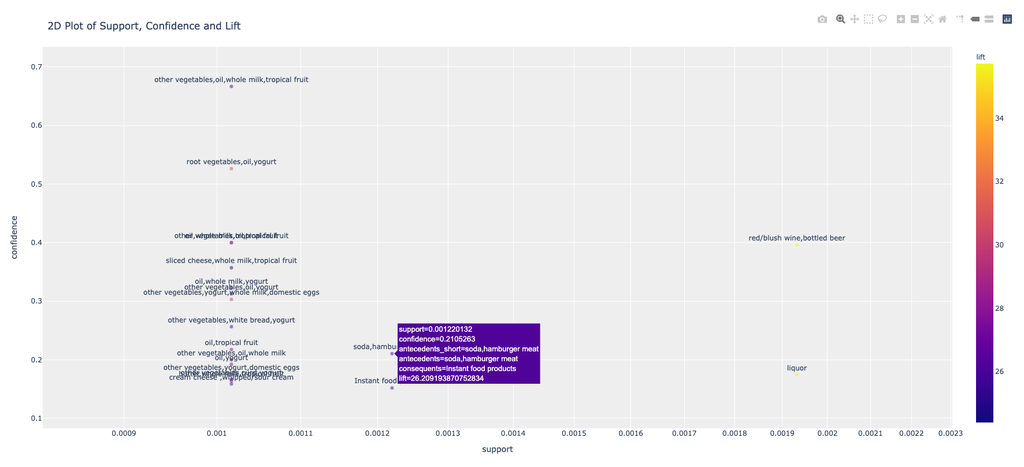

EX:圖上顯示的點代表(soda, hamburger meat) =>(Instant food products)

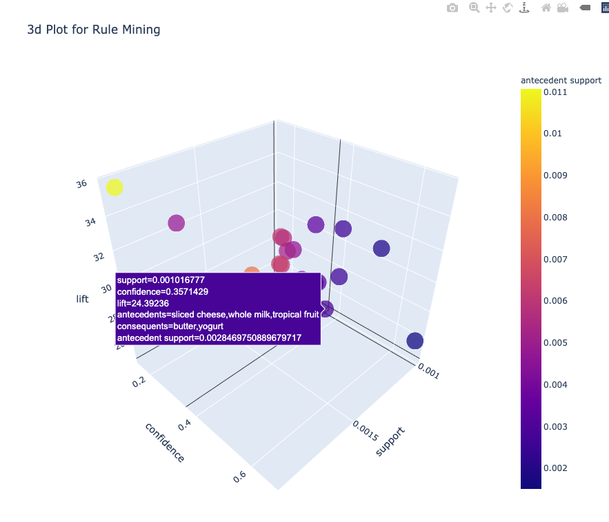

EX:圖上顯示的點代表(sliced cheese, whole milk, tropical fruit) =>(butter, yogurt)

# (30%) Manufacturing System Analysis

## (a) (10%)根據 Little’s Law，試計算各工作站的產出率 TH於下表 ；試問瓶頸站的產出率 𝑟𝑏、最小生產週期時間 (總加工時間， 𝑇0)、關鍵在製品水準 (𝑊0)各為多少？

產品在加工時，經過一種工作站，只需經過此種工作站之一台機台( 一種工作站的所有機台都為平行機台)。

```python
# 產線上工作站總數：N=5
# 週期時間：所有工作站的長期平均加工時間：CT=5+8+12+4+12=41(小時)
# 將機台數視為一次可以接受的WIP
# 瓶頸站產出率 r_b = min(df_3['加工站的產能 TH']) = 0.375
# 關鍵在製品水準：W0 = r_b*T0
# 最小生產週期時間/總加工時間：T0 = CT=5+8+12+4+12=41(小時)

pd.set_option('display.float_format', lambda x: '%.5f' % x)
df_3 = pd.DataFrame()
df_3['工作站編號'] = [1,2,3,4,5]
df_3['機台數 (WIP)'] = [3,3,6,2,5]
df_3['加工時間 t'] = [5,8,12,4,12]
df_3['加工站的產能 TH'] = df_3['機台數 (WIP)'] / df_3['加工時間 t']
display(df_3)
print("瓶頸站：station",df_3['工作站編號'][1])
print("瓶頸站產出率 r_b = ", min(df_3['加工站的產能 TH']))
print("最小生產週期時間/總加工時間：T0 = CT = ", sum(df_3['加工時間 t']))
print("關鍵在製品水準：W0 = r_b*T0 = ", min(df_3['加工站的產能 TH'])*sum(df_3['加工時間 t']))
```

|  | 工作站編號 | 機台數 (WIP) | 加工時間 t | 加工站的產能 TH |
| --- | --- | --- | --- | --- |
| 0 | 1 | 3 | 5 | 0.60000 |
| 1 | 2 | 3 | 8 | 0.37500 |
| 2 | 3 | 6 | 12 | 0.50000 |
| 3 | 4 | 2 | 4 | 0.50000 |
| 4 | 5 | 5 | 12 | 0.41667 |

```
瓶頸站：station 2
瓶頸站產出率 r_b =  0.375
最小生產週期時間/總加工時間：T0 = CT =  41
關鍵在製品水準：W0 = r_b*T0 =  15.375
```

## (b) (10%)試給出最佳績效 (best case)下，最大的產出率 (THbest)與最小生產週期時間 (CTbest)的計算公式 (提示 ：講義 22-29頁)

Best Case:

r_b = 瓶頸站產出率 //0.375

CTbest:

if w<=W0 => CT(w) = T0

if w>W0 => CT(w) = w/r_b

THbest:

if w<=W0 => TH(w) = w/T0

if w>W0 => TH(w) = r_b

```python
# Best Case
W0 = min(df_3['加工站的產能 TH'])*sum(df_3['加工時間 t']) #15.375
r_b = min(df_3['加工站的產能 TH']) #0.375
T0 = sum(df_3['加工時間 t']) #41

# CTbest
# if w<=W0 => CT(w) = T0
# else => CT(w) = w/r_b
CT = []
for w in range(1,50):
    if w <= W0: CT.append(T0)
    else: CT.append(w/r_b)
print("CTbest: ", min(CT))

# THbest
# if w<=W0 => TH(w) = w/T0
# else => TH(w) = r_b
TH = []
for w in range(1,50):
    if w <= W0: TH.append(w/T0)
    else: TH.append(r_b)
print("THbest: ", max(TH))
```

```
CTbest:  41
THbest:  0.375
```

## No (c) (10%)根據該問題的產線，試程式撰寫建立一模擬模型 (或用套裝軟體、數值分析)來 驗證，當在製品WIP數量超過工廠產能時，其生產週期將嚴重惡化。也就是當線的投料速度 (投產量 )大於產線的產出率，此時生產系統將處於非穩定狀態(non-steady state)。 試用圖表呈現 WIP、CT與 TH之間惡化的關係。 (提示 ：講義 22-29頁)

資料來源：https://mattrauch.github.io/2018/06/19/littles-law/

```python
import matplotlib
import matplotlib.pyplot as plt
```

### WIP CT

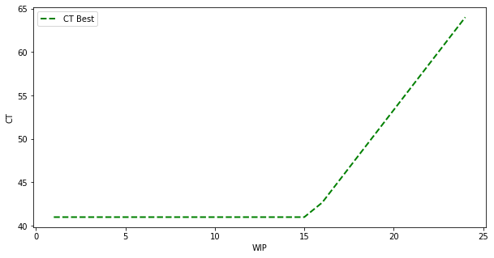

```python
# define variables
W0 = min(df_3['加工站的產能 TH'])*sum(df_3['加工時間 t']) #15.375
r_b = min(df_3['加工站的產能 TH']) #0.375
T0 = sum(df_3['加工時間 t']) #41
maxw = 25

# setup arrays for each line in the plot
wip =[] # WIP levels
CTpwc =[] # practical worst case throughput
CTw =[] # worst case throughput
CTb = [] # best case throughput

# loop through formulas and fill the arrays
for i in range(1,maxw):
    wip.append(i)
    pwc = T0 + (i-1)/r_b
    CTpwc.append(pwc)
    worst = i*T0
    CTw.append(worst)
    if i <= W0:
        best = T0
    else:
        best = i/r_b
    CTb.append(best)

# plot result
plt.figure(figsize = (10,5))
# plt.plot(wip, CTpwc, marker='', color='blue', linewidth=2, label="CT PWC")
# plt.plot(wip, CTw, marker='', color='red', linewidth=2, label="CT Worst")
plt.plot(wip, CTb, marker='', color='green', linewidth=2, linestyle='dashed', label="CT Best")
plt.xlabel("WIP")
plt.ylabel("CT")
plt.legend()
plt.show()
```

### WIP TH

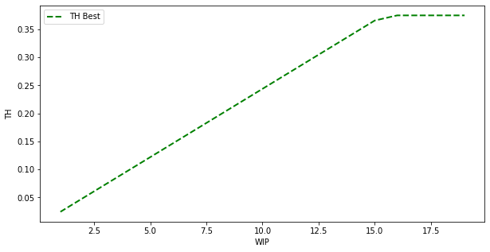

```python
# define variables
W0 = min(df_3['加工站的產能 TH'])*sum(df_3['加工時間 t']) #15.375
r_b = min(df_3['加工站的產能 TH']) #0.375
T0 = sum(df_3['加工時間 t']) #41
maxw = 20

# setup arrays for each line in the plot
wip =[] # WIP levels
THpwc =[] # practical worst case throughput
THw =[] # worst case throughput
THb = [] # best case throughput

# loop through formulas and fill the arrays
for i in range(1,maxw):
    wip.append([i])
    pwc = i/(W0+i-1)*r_b
    THpwc.append([pwc])
    worst = 1/T0
    THw.append([worst])
    if i<=W0:
        best = i/T0
    else:
        best = r_b
    THb.append([best])

# plot result
plt.figure(figsize = (10,5))
# plt.plot(wip, THpwc, marker='', color='blue', linewidth=2, label="TH PWC")
# plt.plot(wip, THw, marker='', color='red', linewidth=2, label="TH Worst")
plt.plot(wip, THb, marker='', color='green', linewidth=2, linestyle='dashed', label="TH Best")
plt.xlabel("WIP")
plt.ylabel("TH")
plt.legend()
plt.show()
```